# Love vs extraterrestials

Evangela Mcgarity

Spring 2020

# A question of Belief

Your data is in the dataframe called “mydata” examine it in the environment tab  
do a variable analysis on the 3 Questions and then upload the appropriate Rmd template for this job.  
Also create an empty github repository called “Belief” and make it the remote repository for  
this assignment. For each question supply graphical evidence, numerical summaries, an inferential test, and a conclusion. When finished push your rmd file, your project file, and your knitted html file to your github repo. Finally turn in to Canvas the link to your github repo.

# Your First Question

### Do people who believe in Love at First sight also tend to believe in Life on other planets?

$H_0$: There is no belief in love at first site and belief in et. $A_A$: there is belief in love at first site and in et.

graphic display

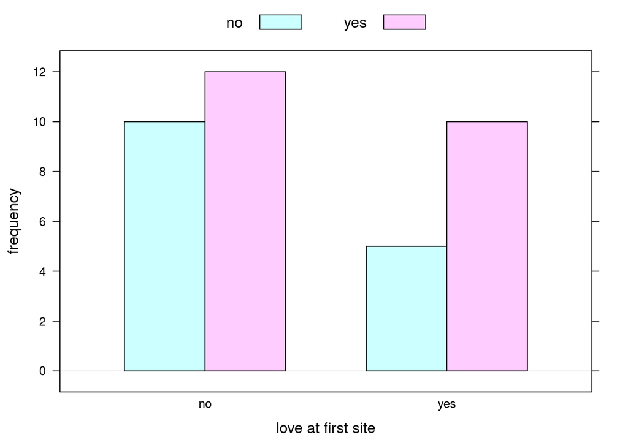

```r
barchartGC(~love_first + extra_life,data=mydata, xlab="love at first site")
```

people who believe in first site also tend to beleive in et

numerical summary

```r
table1 <- xtabs(~love_first + extra_life, data=mydata)
rowPerc(table1)
```

```
##           extra_life
## love_first     no    yes  Total
##        no   45.45  54.55 100.00
##        yes  33.33  66.67 100.00
```

```r
colPerc(table1)
```

```
##           extra_life
## love_first     no    yes
##      no     66.67  54.55
##      yes    33.33  45.45
##      Total 100.00 100.00
```

it looks about the same

inference

```r
chisq.test(table1)
```

```
##
##  Pearson's Chi-squared test with Yates' continuity correction
##
## data:  table1
## X-squared = 0.15705, df = 1, p-value = 0.6919
```

```r
chisqtestGC(table1)
```

```
## Pearson's Chi-squared test with Yates' continuity correction
##
## Observed Counts:
##           extra_life
## love_first no yes
##        no  10  12
##        yes  5  10
##
## Counts Expected by Null:
##           extra_life
## love_first   no   yes
##        no  8.92 13.08
##        yes 6.08  8.92
##
## Contributions to the chi-square statistic:
##           extra_life
## love_first   no  yes
##        no  0.13 0.09
##        yes 0.19 0.13
##
##
## Chi-Square Statistic = 0.1571
## Degrees of Freedom of the table = 1
## P-Value = 0.6919
```

```r
fisher.test(table1)
```

```
##
##  Fisher's Exact Test for Count Data
##
## data:  table1
## p-value = 0.5144
## alternative hypothesis: true odds ratio is not equal to 1
## 95 percent confidence interval:
##  0.3559477 8.3319485
## sample estimates:
## odds ratio
##   1.643815
```

We fail to reject it,there has no evidence to support the contention because the p value is higher then p<0.05

# Your second Question

### Is there a difference between boys and girls with respect to belief in life on other planets?

$H_0$: There is no relation between boys and girls belief in life on other planets. $A_A$: there is belief in life on ither planets between boys and girls.

graphical summary

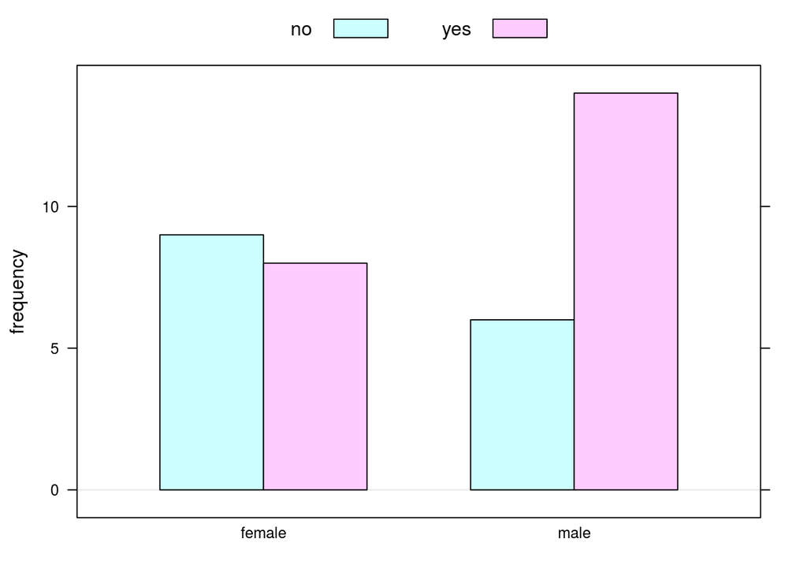

```r
barchartGC(~sex + extra_life,data=mydata)
```

Boys seems to believe in life on other planet more than girls

numerical summary

```r
table1 <- xtabs(~sex + extra_life, data=mydata)
rowPerc(table1)
```

```
##         extra_life
## sex          no    yes  Total
##   female  52.94  47.06 100.00
##   male    30.00  70.00 100.00
```

```r
colPerc(table1)
```

```
##         extra_life
## sex       no    yes
##   female  60  36.36
##   male    40  63.64
##   Total  100 100.00
```

Inference

```r
chisq.test(table1)
```

```
##
##  Pearson's Chi-squared test with Yates' continuity correction
##
## data:  table1
## X-squared = 1.1675, df = 1, p-value = 0.2799
```

```r
chisqtestGC(table1)
```

```
## Pearson's Chi-squared test with Yates' continuity correction
##
## Observed Counts:
##         extra_life
## sex      no yes
##   female  9   8
##   male    6  14
##
## Counts Expected by Null:
##         extra_life
## sex        no   yes
##   female 6.89 10.11
##   male   8.11 11.89
##
## Contributions to the chi-square statistic:
##         extra_life
## sex        no  yes
##   female 0.64 0.44
##   male   0.55 0.37
##
##
## Chi-Square Statistic = 1.1675
## Degrees of Freedom of the table = 1
## P-Value = 0.2799
```

```r
fisher.test(table1)
```

```
##
##  Fisher's Exact Test for Count Data
##
## data:  table1
## p-value = 0.1931
## alternative hypothesis: true odds ratio is not equal to 1
## 95 percent confidence interval:
##   0.5642317 12.5617008
## sample estimates:
## odds ratio
##   2.554567
```

we fail to reject the hypotheseis because the p value is higher then 0.05